# New cases of COVID-19 through time

Doug McNeall

6/5/2020

## Introduction

This vignette examines some estimates of UK cases of COVID-19 through time. These data should prove useful in the history matching of MetaWards.

### ONS data direct estimates of infections.

These surveys measure the number of people who have COVID-19 at a particular time via a survey. They were conducted by the Office for National Statistics weekly and released on the following days:

5th June 2020 https://www.ons.gov.uk/peoplepopulationandcommunity/healthandsocialcare/conditionsanddiseases/bulletins/coronaviruscovid19infectionsurveypilot/5june2020

On cumulative total infections, from the 5th June report:

“As of 24 May 2020, 6.78% (95% confidence interval: 5.21% to 8.64%) of individuals from whom blood samples were taken tested positive for antibodies to the coronavirus (COVID-19). This is based on blood test results from 885 individuals since the start of the study on 26 April 2020.”

28th May 2020 https://www.ons.gov.uk/peoplepopulationandcommunity/healthandsocialcare/conditionsanddiseases/bulletins/coronaviruscovid19infectionsurveypilot/28may2020

21st May 2020 https://www.ons.gov.uk/peoplepopulationandcommunity/healthandsocialcare/conditionsanddiseases/bulletins/coronaviruscovid19infectionsurveypilot/england21may2020

14th May 2020 https://www.ons.gov.uk/peoplepopulationandcommunity/healthandsocialcare/conditionsanddiseases/bulletins/coronaviruscovid19infectionsurveypilot/england14may2020

# ONS cases (absolute numbers in England)

# Incidence rate is new cases per week per 100 people

start_date end_date cases_med cases_lower95 cases_upper95 prop_med prop_lower95 prop_upper95 new_cases_med new_cases_lower95 new_cases_upper95 incidence_rate 2020-04-27 2020-05-10 148000 94000 222000 0.27 0.17 0.41 NA NA NA 2020-05-04 2020-05-17 137000 85000 208000 0.25 0.16 0.38 61000 29000 111000 0.11 2020-05-11 2020-05-24 133000 62000 250000 0.24 0.11 0.46 54000 34000 86000 0.10 2020-05-17 2020-05-30 53000 25000 99000 0.10 0.05 0.18 39000 26000 55000 0.07

# Also check out Cambridge MRC estimates

https://www.mrc-bsu.cam.ac.uk/tackling-covid-19/nowcasting-and-forecasting-of-covid-19/ https://www.mrc-bsu.cam.ac.uk/now-casting/

ONS data (hand edited from the reports)

```r
ons <- read.csv("../data/ons_covid_infection_survey.csv", header = TRUE, na.strings = c('NA'))
```

These data report the daily new lab-confirmed cases of COVID-19

```r
dat <- read.csv('https://coronavirus.data.gov.uk/downloads/csv/coronavirus-cases_latest.csv')
```

Use only England data, to match the ONS

```r
england <- dat[dat[,'Area.name']=='England', ]

init <- data.frame('Specimen.date' = as.Date(england[,'Specimen.date']), 'Daily.lab.confirmed.cases' = england[,'Daily.lab.confirmed.cases'])

library(tidyverse)
library(lubridate)
weekly_new_cases <- init %>%
  group_by(week = format(Specimen.date, '%Y-%U')) %>%
  #group_by(year = year(Specimen.date), week = week(Specimen.date)) %>%
  summarise(weekly_sum = sum(Daily.lab.confirmed.cases))

# manually calculate the date axis for now
week_ax = seq(from = min(as.Date(england[, 'Specimen.date'])), to = max(as.Date(england[, 'Specimen.date'])), by = 7)

ons_midpoints <- as.Date(c("2020-05-03","2020-05-10","2020-05-17","2020-05-24"))
```

Interpolate the weekly cases from the data.

```r
library(DiceKriging)

# Gaussian process fit for the aggregated new cases timeseries.
cases.fit <- km(~., design = as.matrix(week_ax, ncol = 1), response = weekly_new_cases$weekly_sum)
```

[output not shown]

```r
# Predict the cases at the timepoints where we have the ONS measurements.
pred <- predict.km(cases.fit, newdata = as.matrix(ons_midpoints, ncol = 1), type = 'UK')
```

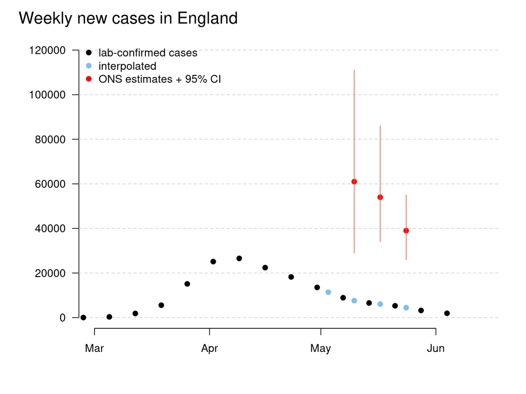

```r
par(mar = c(5,6,3,2), las = 1)
plot(week_ax, weekly_new_cases$weekly_sum,
     ylim = c(0, 120000), xlim = as.Date(c("2020-03-01", "2020-06-14")),
     xlab = '', ylab = '',
     pch = 19,
     bty = 'n',
     type = 'n')
abline(h = seq(from = 0,  to = 120000, by = 20000), col = 'lightgrey', lty = 'dashed')
points(week_ax, weekly_new_cases$weekly_sum, pch = 19)
points(ons_midpoints, ons[,'new_cases_med'], col = 'red', pch = 19)
points(ons_midpoints, pred$mean, col = 'skyblue2', pch = 19)
segments(x0 = ons_midpoints, y0 = ons[,'new_cases_lower95'], x1 = ons_midpoints, y1 = ons[,'new_cases_upper95'], col = 'tomato2')
mtext('Weekly new cases in England', side = 3, adj = 0.06, line = -2,outer = TRUE, cex = 1.5)
legend('topleft', pch = 19, col = c('black', 'skyblue2','red'),
       legend = c('lab-confirmed cases', 'interpolated', 'ONS estimates + 95% CI'),
       bty = 'n')
```

Now we can get an estimate of the proportion of new cases that are picked up daily (and aggregated to weekly), compared to the ONS survey results.

```r
prop_recorded_cases <- pred$mean / ons[,'new_cases_med']
print(data.frame(ons_midpoints, prop_recorded_cases))
```

```
##   ons_midpoints prop_recorded_cases
## 1    2020-05-03                  NA
## 2    2020-05-10           0.1248596
## 3    2020-05-17           0.1126028
## 4    2020-05-24           0.1145973
```

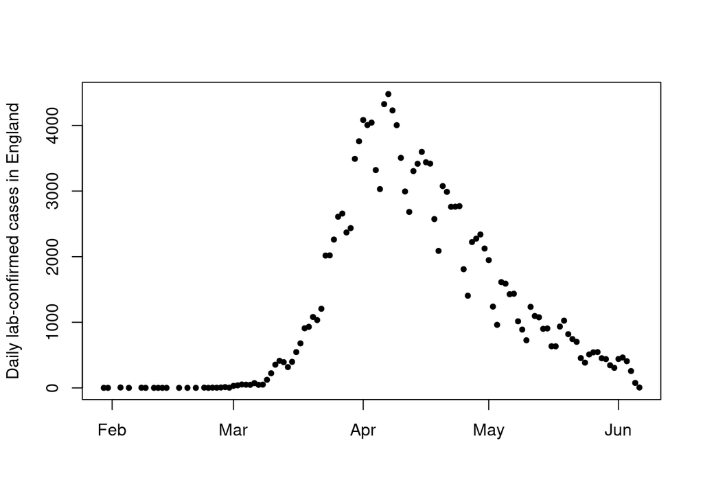

```r
#plot(dat$end_date, dat$new_cases_med)
plot(as.Date(england[, 'Specimen.date']), england[, 'Daily.lab.confirmed.cases'], pch = 20,
     ylab = 'Daily lab-confirmed cases in England', xlab = '')
```